# Lab#8

Ifeoma Okonye

2024-03-27

## Introduction

To begin, I imported the required datalayers. The layers were landuse of 2016 - 2019 for riley county and the wildcat creek watershed shapefile. I then did some tidying and made sure all data layers were in the right coordinate reference system.

```r
#rm(list = ls())

library(pacman)
p_load(raster, terra, sf, tidyverse)

#loading in the data
wcw <- st_read("Data/Wildcat_creek_Watershed/Wildcat_creek_Watershed.shp")
riley2016 <- rast("Data/Cropland_Data/CDL_2016_20161.tif")
riley2016
```

```
## class       : SpatRaster
## dimensions  : 1966, 1632, 1  (nrow, ncol, nlyr)
## resolution  : 30, 30  (x, y)
## extent      : -82245, -33285, 1779825, 1838805  (xmin, xmax, ymin, ymax)
## coord. ref. : +proj=aea +lat_0=23 +lon_0=-96 +lat_1=29.5 +lat_2=45.5 +x_0=0 +y_0=0 +datum=NAD83 +units=m +no_defs
## source      : CDL_2016_20161.tif
## color table : 1
## categories  : CLASS_NAME, RED, GREEN, BLUE, OPACITY
## name        : CLASS_NAME
## min value   :         NA
## max value   :         NA
```

```r
riley2017 <- rast("Data/Cropland_Data/CDL_2017_20161.tif")
riley2017
```

```
## class       : SpatRaster
## dimensions  : 1966, 1632, 1  (nrow, ncol, nlyr)
## resolution  : 30, 30  (x, y)
## extent      : -82245, -33285, 1779825, 1838805  (xmin, xmax, ymin, ymax)
## coord. ref. : +proj=aea +lat_0=23 +lon_0=-96 +lat_1=29.5 +lat_2=45.5 +x_0=0 +y_0=0 +datum=NAD83 +units=m +no_defs
## source      : CDL_2017_20161.tif
## color table : 1
## categories  : CLASS_NAME, RED, GREEN, BLUE, OPACITY
## name        : CLASS_NAME
## min value   :         NA
## max value   :         NA
```

```r
riley2018 <- rast("Data/Cropland_Data/CDL_2018_20161.tif")
riley2018
```

```
## class       : SpatRaster
## dimensions  : 1966, 1632, 1  (nrow, ncol, nlyr)
## resolution  : 30, 30  (x, y)
## extent      : -82245, -33285, 1779825, 1838805  (xmin, xmax, ymin, ymax)
## coord. ref. : +proj=aea +lat_0=23 +lon_0=-96 +lat_1=29.5 +lat_2=45.5 +x_0=0 +y_0=0 +datum=NAD83 +units=m +no_defs
## source      : CDL_2018_20161.tif
## color table : 1
## categories  : CLASS_NAME, RED, GREEN, BLUE, OPACITY
## name        : CLASS_NAME
## min value   :         NA
## max value   :         NA
```

```r
riley2019 <- rast("Data/Cropland_Data/CDL_2019_20161.tif")
riley2019
```

```
## class       : SpatRaster
## dimensions  : 1966, 1632, 1  (nrow, ncol, nlyr)
## resolution  : 30, 30  (x, y)
## extent      : -82245, -33285, 1779825, 1838805  (xmin, xmax, ymin, ymax)
## coord. ref. : +proj=aea +lat_0=23 +lon_0=-96 +lat_1=29.5 +lat_2=45.5 +x_0=0 +y_0=0 +datum=NAD83 +units=m +no_defs
## source      : CDL_2019_20161.tif
## color table : 1
## categories  : RED, GREEN, BLUE, CLASS_NAME, OPACITY
## name        : RED
## min value   :  NA
## max value   :  NA
```

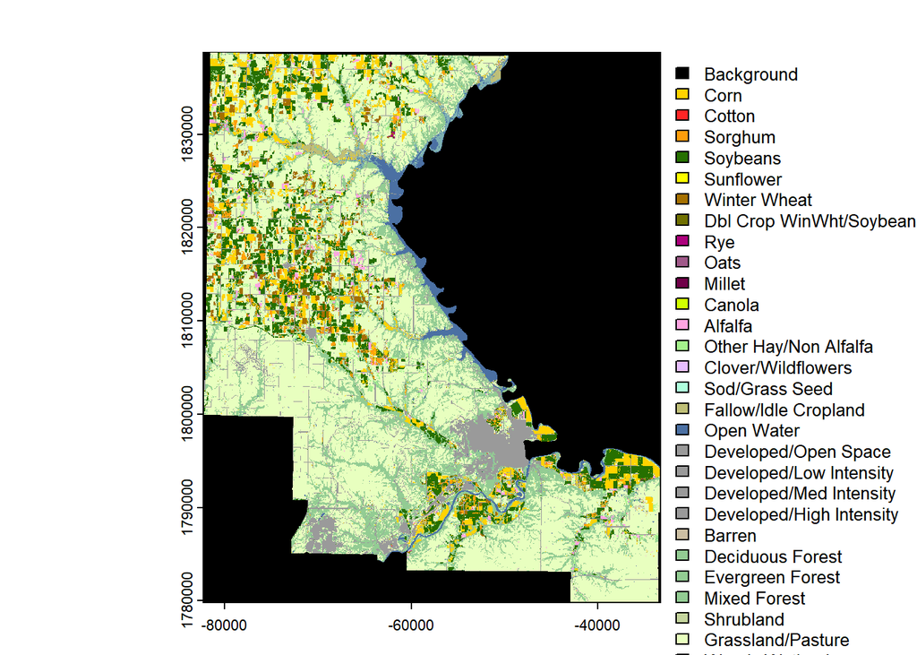

```r
#Because all other raster dataset are using the correct data name except 2019, I activate riley 2019 to the class_name column

activeCat(riley2019) <- 4
plot(riley2019)
```

```r
#looking at the dataset
minmax(riley2016, compute = T)
```

```
##     CLASS_NAME
## min          0
## max        241
```

```r
minmax(riley2017, compute = T)
```

```
##     CLASS_NAME
## min          0
## max        254
```

```r
minmax(riley2018, compute = T)
```

```
##     CLASS_NAME
## min          0
## max        236
```

```r
minmax(riley2019, compute = T)
```

```
##     CLASS_NAME
## min          0
## max        240
```

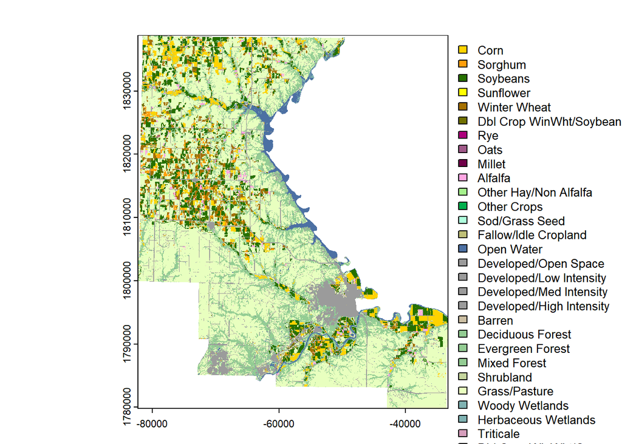

```r
riley2016[riley2016 == 0] <- NA
riley2017[riley2017 == 0] <- NA
riley2018[riley2018 == 0] <- NA
riley2019[riley2019 == 0] <- NA

riley2016 <- trim(riley2016)
riley2017 <- trim(riley2017)
riley2018 <- trim(riley2018)
riley2019 <- trim(riley2019)



plot(riley2016)
```

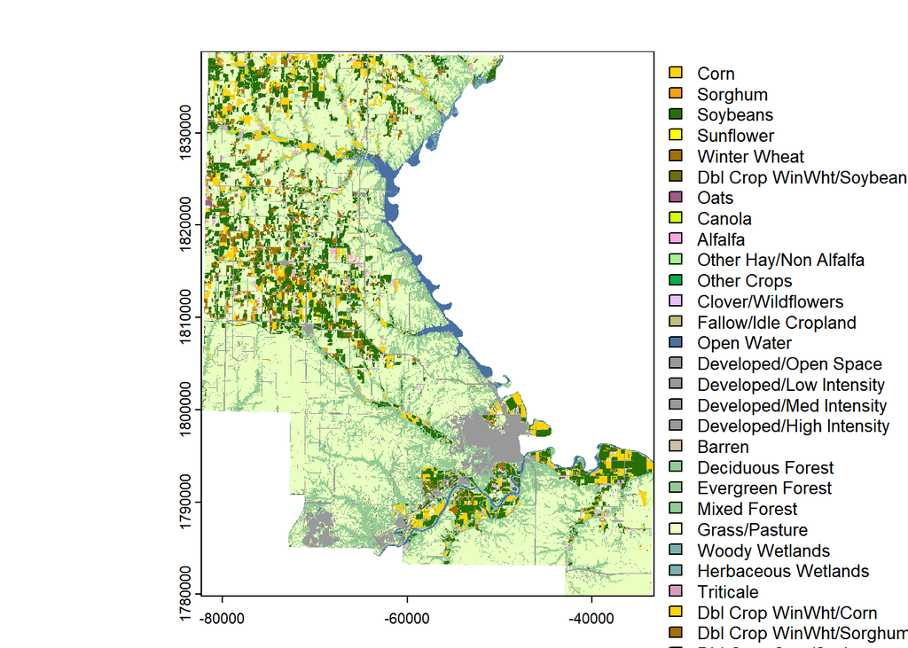

```r
plot(riley2017)
```

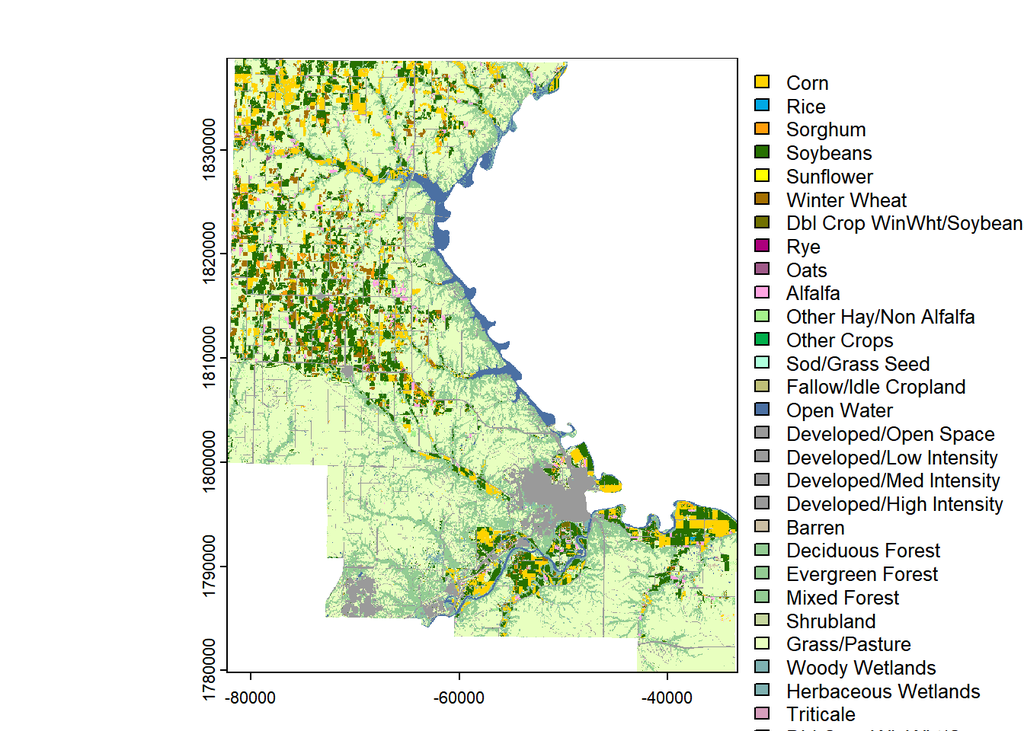

```r
plot(riley2018)
```

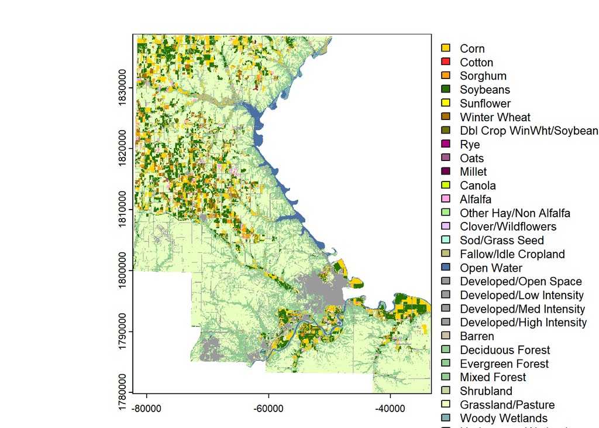

```r
plot(riley2019)
```

```r
#removing missing values



#setting crs

crs(riley2016)
```

```
## [1] "PROJCRS[\"unnamed\",\n    BASEGEOGCRS[\"NAD83\",\n        DATUM[\"North American Datum 1983\",\n            ELLIPSOID[\"GRS 1980\",6378137,298.257222101004,\n                LENGTHUNIT[\"metre\",1]]],\n        PRIMEM[\"Greenwich\",0,\n            ANGLEUNIT[\"degree\",0.0174532925199433]],\n …
```

```r
st_crs(wcw)
```

```
## Coordinate Reference System:
##   User input: NAD83
##   wkt:
## GEOGCRS["NAD83",
##     DATUM["North American Datum 1983",
##         ELLIPSOID["GRS 1980",6378137,298.257222101,
##             LENGTHUNIT["metre",1]]],
##     PRIMEM["Greenwich",0,
##         ANGLEUNIT["degree",0.0174532925199433]],
##     CS[ellipsoidal,2],
##         AXIS["latitude",north,
##             ORDER[1],
##             ANGLEUNIT["degree",0.0174532925199433]],
##         AXIS["longitude",east,
##             ORDER[2],
##             ANGLEUNIT["degree",0.0174532925199433]],
##     ID["EPSG",4269]]
```

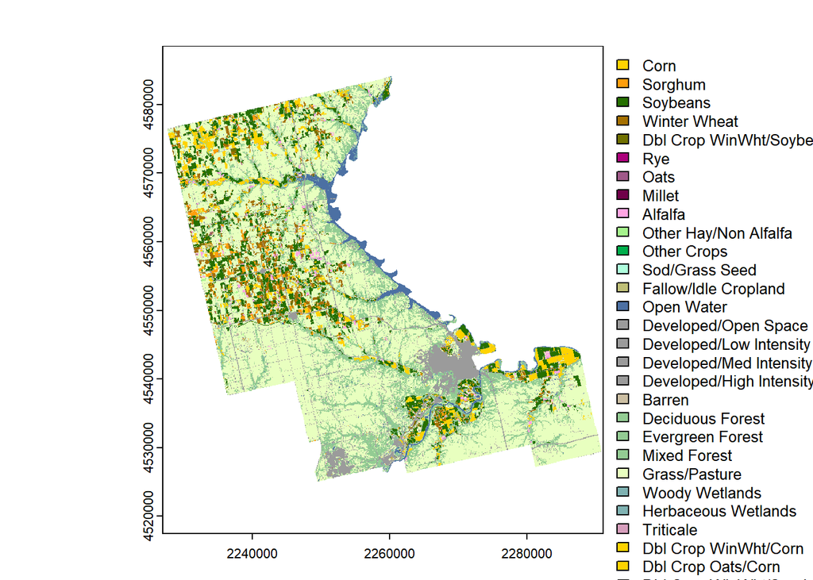

```r
crs <- '+proj=utm +zone=11 +ellps=GRS80 +datum=NAD83 +units=m +no_defs'

# Use project for SpatRasters in terra

riley2016 <- project(riley2016, crs, res = res(riley2016), method = "near")

riley2017 <- project(riley2017, crs, res = res(riley2017), method = "near")

riley2018 <- project(riley2018, crs, res = res(riley2018), method = "near")

riley2019 <- project(riley2019, crs, res = res(riley2019), method = "near")

plot(riley2016)
```

### Question 1

I created a new raster by subsetting the raster layers so that they are smaller and closer to the area of interest using the crop function. Then I used the mask function to clip the rasters to the watershed extent.

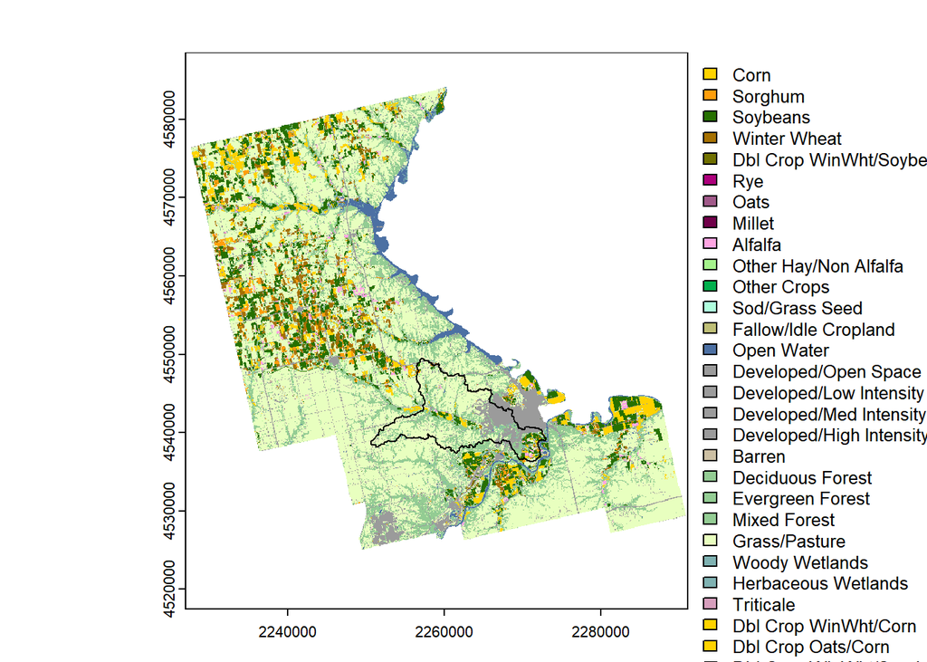

```r
# To convert the crs of the watershed data to be the same as riley

wcw <- st_transform(wcw, crs = crs)

plot(riley2016)
plot(wcw, col = NA, add = T)
```

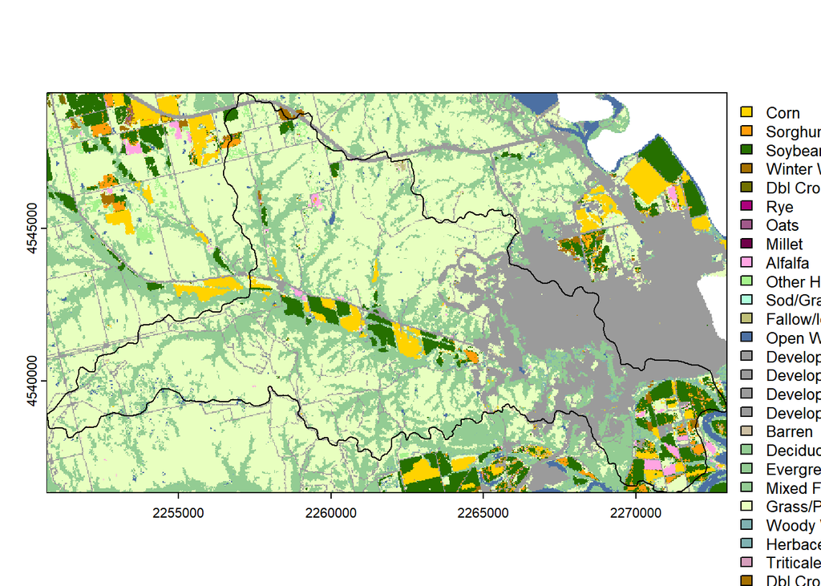

```r
#cropping out the watershed

wcw_rc2016 <- crop(riley2016, wcw)
plot(wcw_rc2016)
plot(wcw, col = NA, add = T)
```

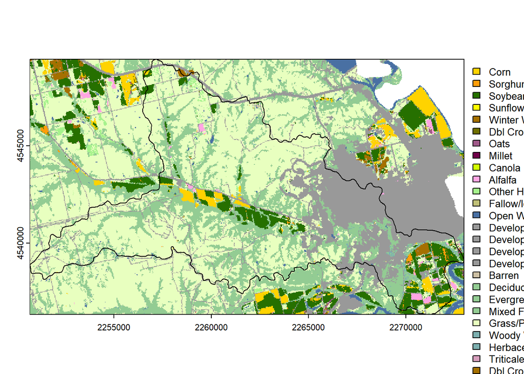

```r
wcw_rc2017 <- crop(riley2017, wcw)
plot(wcw_rc2017)
plot(wcw, col = NA, add = T)
```

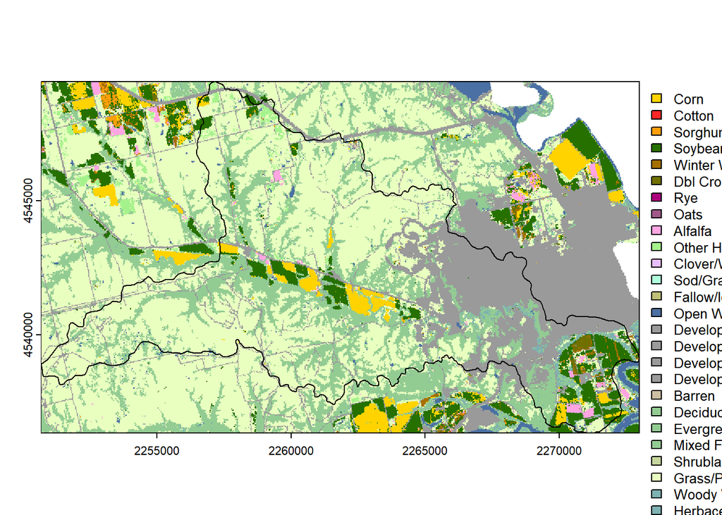

```r
wcw_rc2018 <- crop(riley2018, wcw)
plot(wcw_rc2018)
plot(wcw, col = NA, add = T)
```

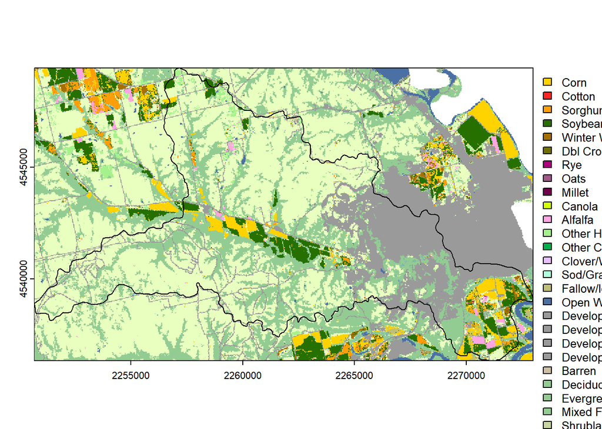

```r
wcw_rc2019 <- crop(riley2019, wcw)
plot(wcw_rc2019)
plot(wcw, col = NA, add = T)
```

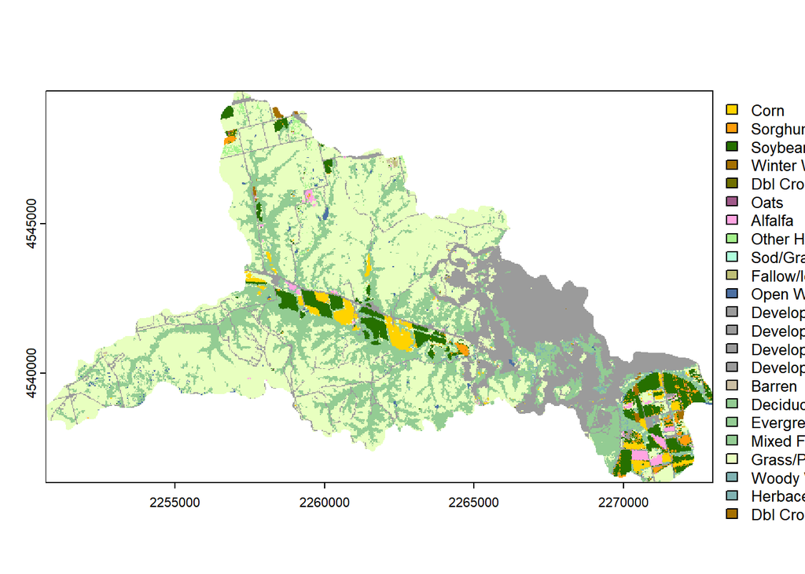

```r
#masking out the watershed

wcw_rc2016m <- mask(wcw_rc2016, mask = wcw)
plot(wcw_rc2016m)
```

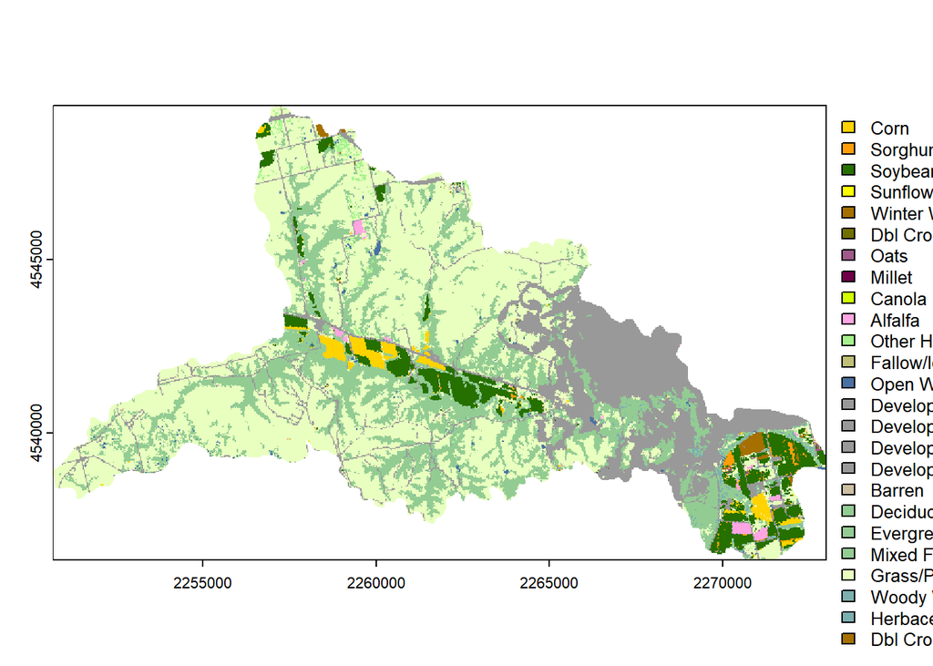

```r
wcw_rc2017m <- mask(wcw_rc2017, mask = wcw)
plot(wcw_rc2017m)
```

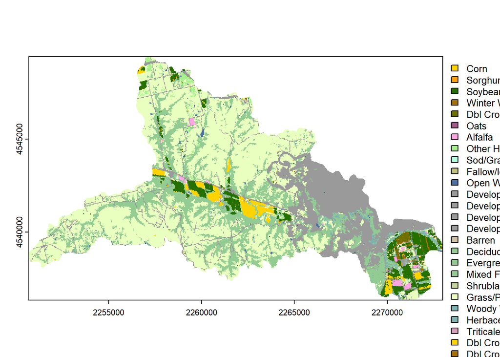

```r
wcw_rc2018m <- mask(wcw_rc2018, mask = wcw)
plot(wcw_rc2018m)
```

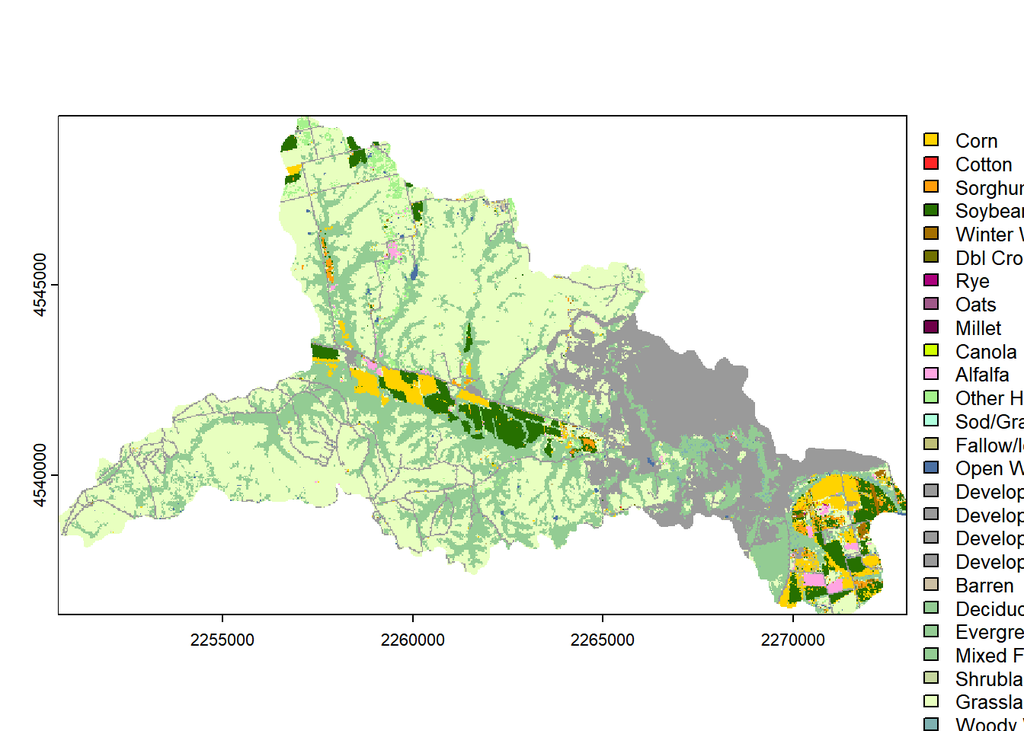

```r
wcw_rc2019m <- mask(wcw_rc2019, mask = wcw)
plot(wcw_rc2019m)
```

### Question 2

```r
freq2016 <- freq(wcw_rc2016m)
most_common_landuse2016 <- freq2016[which.max(freq2016$count), ]
most_common_landuse2016
```

```
##    layer         value count
## 20     1 Grass/Pasture 63444
```

```r
freq2017 <- freq(wcw_rc2017m)
most_common_landuse2017 <- freq2017[which.max(freq2017$count), ]
most_common_landuse2017
```

```
##    layer         value count
## 22     1 Grass/Pasture 62074
```

```r
freq2018 <- freq(wcw_rc2018m)
most_common_landuse2018 <- freq2018[which.max(freq2018$count), ]
most_common_landuse2018
```

```
##    layer         value count
## 21     1 Grass/Pasture 62169
```

```r
freq2019 <- freq(wcw_rc2019m)
most_common_landuse2019 <- freq2019[which.max(freq2019$count), ]
most_common_landuse2019
```

```
##    layer             value count
## 25     1 Grassland/Pasture 59470
```

### Question 3

I created two new raster layers. One displayed the locations where land use type in 2016 and 2019 is different, and the other displayed the most frequent land use type across all years within the watershed.

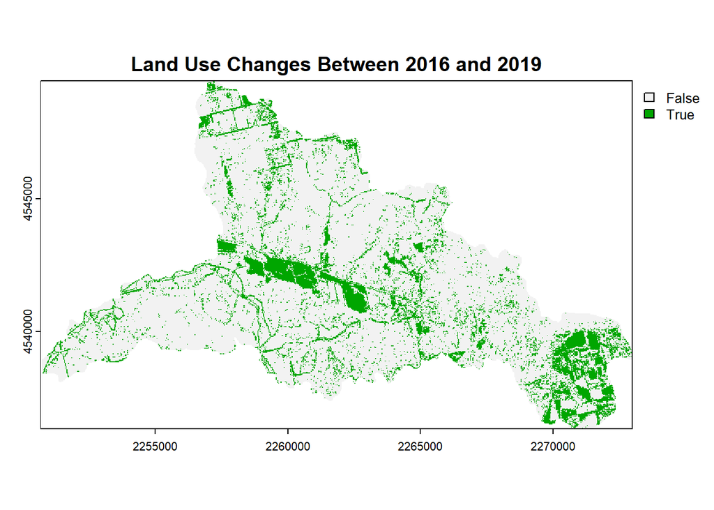

```r
# Identifying Changes Between 2016 and 2019

# Create raster highlighting changes (True = changed, False = unchanged)
changes16_19 <- wcw_rc2016m != wcw_rc2019m

# Plot the changes
plot(changes16_19, main = "Land Use Changes Between 2016 and 2019")
```

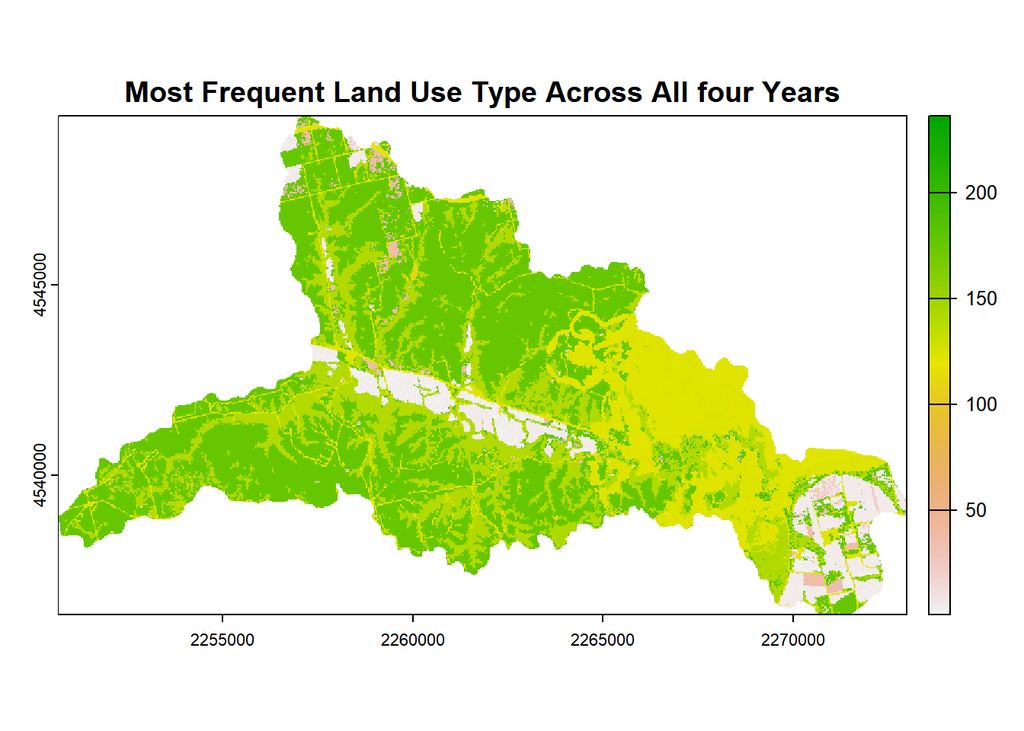

```r
# Identifying the Most Frequent Land Use Type Across All Years

# Stack all yearly land use rasters
Landuse_all_years <- c(wcw_rc2016m, wcw_rc2017m, wcw_rc2018m, wcw_rc2019m)


# Use the 'modal' function to find the most frequent value (mode) across the layers for each cell
most_frequent_landuse <- app(Landuse_all_years, fun = modal, na.rm = T)


# Plot the most frequent land use type
plot(most_frequent_landuse, main = "Most Frequent Land Use Type Across All four Years")
```

### Question 4

I increased the size of the raster grid cells of the 2019 watershed land use raster by a factor of 10 using the resample function. In this new low resolution raster layer, the most common landuse type for 2019 was still Grass/Pasture but the count went from 59,470 in the high resolution layer to 601 in the low resolution data. From the analysis, the landuses in the low resolution data seems to have been reduced from 29 landuses (in the high resolution layer) to 19 land uses. There was a reduction of 10 landuses. I also plotted the coarser (low resolution) raster.

```r
#checking resolutions
res(wcw_rc2016m)
```

```
## [1] 30 30
```

```r
res(wcw_rc2017m)
```

```
## [1] 30 30
```

```r
res(wcw_rc2018m)
```

```
## [1] 30 30
```

```r
res(wcw_rc2019m)
```

```
## [1] 30 30
```

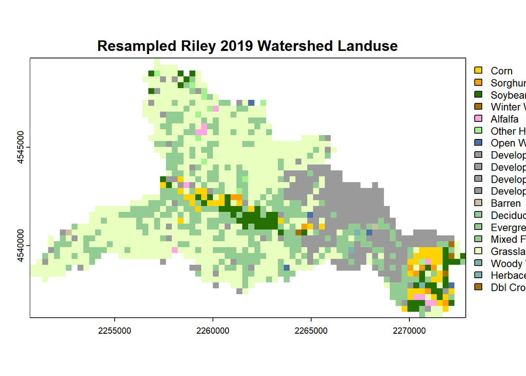

```r
# Increasing size of raster grid cell by a factor of 10
new_ras <- rast(crs = crs,
                  ext = ext(wcw_rc2019m),
                  resolution = c(300, 300))


wcw_rc2019m_resampled <- resample(wcw_rc2019m, new_ras,
                                  method = "ngb")

plot(wcw_rc2019m_resampled, main = "Resampled Riley 2019 Watershed Landuse")
```

```r
# Determine most common land use of this lower resolution raster

freq2019_resampled <- freq(wcw_rc2019m_resampled)

most_common_landuse2019_rsp <- freq2019_resampled[which.max(freq2019_resampled$count), ]
most_common_landuse2019_rsp
```

```
##    layer             value count
## 16     1 Grassland/Pasture   601
```

```r
# Determine if all land uses in high res raster are found in lower res raster

high_res_lu <- unique(wcw_rc2019m$CLASS_NAME)
count(high_res_lu)
```

```
##    n
## 1 29
```

```r
high_res_lu
```

```
##                  CLASS_NAME
## 1                      Corn
## 2                    Cotton
## 3                   Sorghum
## 4                  Soybeans
## 5              Winter Wheat
## 6  Dbl Crop WinWht/Soybeans
## 7                       Rye
## 8                      Oats
## 9                    Millet
## 10                   Canola
## 11                  Alfalfa
## 12    Other Hay/Non Alfalfa
## 13           Sod/Grass Seed
## 14     Fallow/Idle Cropland
## 15               Open Water
## 16     Developed/Open Space
## 17  Developed/Low Intensity
## 18  Developed/Med Intensity
## 19 Developed/High Intensity
## 20                   Barren
## 21         Deciduous Forest
## 22         Evergreen Forest
## 23             Mixed Forest
## 24                Shrubland
## 25        Grassland/Pasture
## 26           Woody Wetlands
## 27      Herbaceous Wetlands
## 28                Triticale
## 29  Dbl Crop WinWht/Sorghum
```

```r
low_res_lu <- unique(wcw_rc2019m_resampled$CLASS_NAME)
count(low_res_lu)
```

```
##    n
## 1 19
```

```r
low_res_lu
```

```
##                  CLASS_NAME
## 1                      Corn
## 2                   Sorghum
## 3                  Soybeans
## 4              Winter Wheat
## 5                   Alfalfa
## 6     Other Hay/Non Alfalfa
## 7                Open Water
## 8      Developed/Open Space
## 9   Developed/Low Intensity
## 10  Developed/Med Intensity
## 11 Developed/High Intensity
## 12                   Barren
## 13         Deciduous Forest
## 14         Evergreen Forest
## 15             Mixed Forest
## 16        Grassland/Pasture
## 17           Woody Wetlands
## 18      Herbaceous Wetlands
## 19  Dbl Crop WinWht/Sorghum
```

### Question 5

I resampled the 2019 landuse raster to 1 kilometer and then I plotted it. Using visual inspection, I could see that a lot of the detail in the data and the representation of different land use types had been lost. ALso the legend from the plot shows that the landuses had reduced. Using the freq function,I compared the frequency of different land use types between the two rasters and saw significant changes in the frequency of land use types which indicate areas where finer details were lost in the resampling process. The landuse types went from 29 in the high resolution raster to 12 in the resampled raster and also the frequency of the most common landuse (Grassland/Pasture), went down to a count of 55.

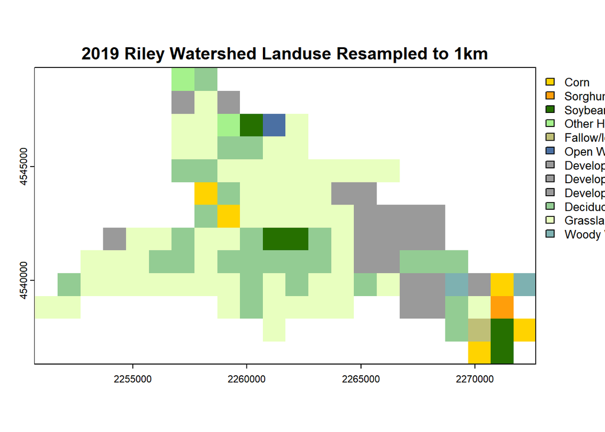

```r
# Adjusting size of raster grid cell to 1000m (1km x 1km)
new_ras_1km <- rast(crs = crs,
                  ext = ext(wcw_rc2019m),
                  resolution = c(1000, 1000))




wcw_rc2019m_r1km <- resample(wcw_rc2019m, new_ras_1km,
                                  method = "ngb")

plot(wcw_rc2019m_r1km, main = "2019 Riley Watershed Landuse Resampled to 1km")
```

```r
# Compare coarse resolution raster to original high resolution raster  and if the landuses are the same


#coarse res
freq2019_res1km <- freq(wcw_rc2019m_r1km)
count(freq2019_res1km)
```

```
##    n
## 1 12
```

```r
most_common_landuse2019_rsp1km <- freq2019_res1km[which.max(freq2019_res1km$count), ]
most_common_landuse2019_rsp1km
```

```
##    layer             value count
## 11     1 Grassland/Pasture    55
```

```r
#high res
freq2019 <- freq(wcw_rc2019m)
count(freq2019)
```

```
##    n
## 1 29
```

```r
most_common_landuse2019 <- freq2019[which.max(freq2019$count), ]
most_common_landuse2019
```

```
##    layer             value count
## 25     1 Grassland/Pasture 59470
```